# Pinnacle Upholsters

Sales Department

# Introduction

This report describes the sales made by Pinnacle Upholsters for the month of `June` in `2013`. Goods sold are divided into `3` distinct segments,i.e `Consumer`, `Corporate` and `Home Office`. Each of these segments are further divided into `4` ship modes, namely: `First Class`, `Same Day`, `Second Class` and `Standard Class`

## Consumer

### First Class

- Total sales made: Ksh. 23.12

### Same Day

- Total sales made: Ksh. 310.688

### Second Class

- Total sales made: Ksh. 1866.97

### Standard Class

- Total sales made: Ksh. 2189.121

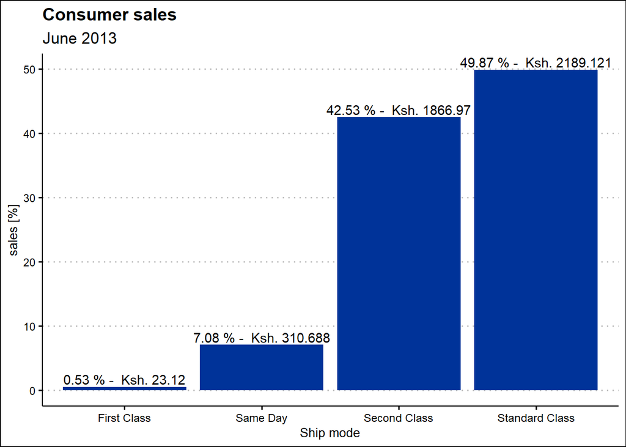

## Corporate

### First Class

- Total sales made: Ksh. 0

### Same Day

- Total sales made: Ksh. 0

### Second Class

- Total sales made: Ksh. 0

### Standard Class

- Total sales made: Ksh. 170.352

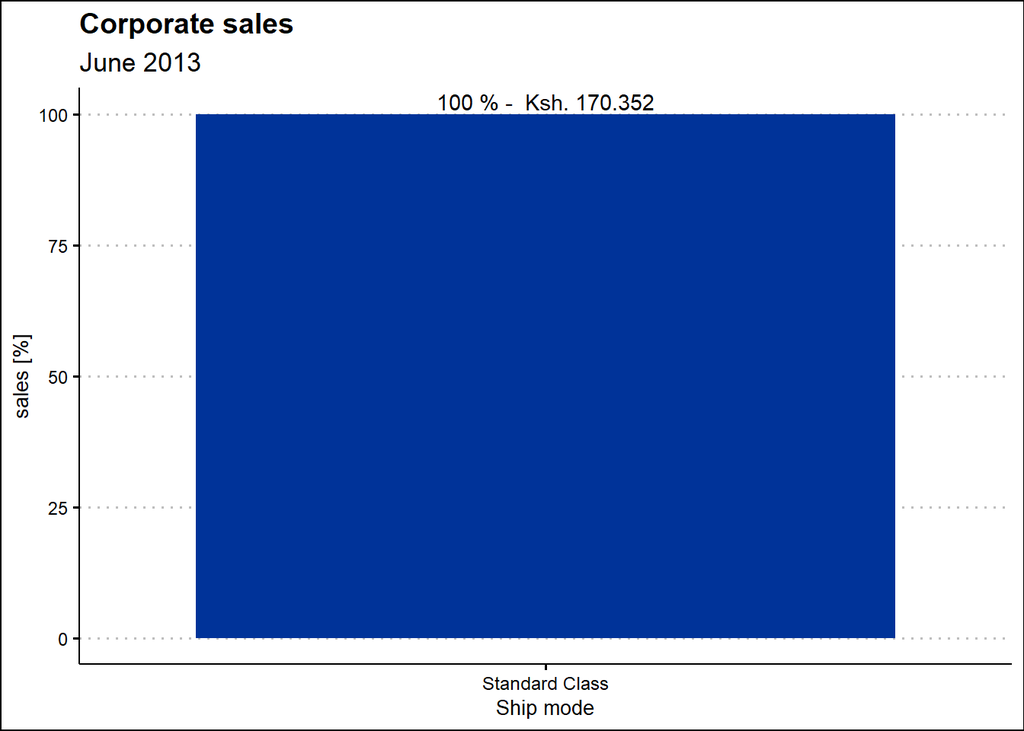